# Predicting 2022 CFB Games

# What is this?

This page displays predictions for games in the 2022 CFB season. These predictions come from a model built on historical college football play by play and game data in order to simulate upcoming games. All data is from collegefootballdata.com.

# Week 13 Predictions

This table displays the results of simulating week 13 of the 2022 CFB season 1000 times. These simulations are run one week in advance, using information available in the lead up to week 13. For the first week of the season, team ratings are based solely on information from previous seasons.

**Quality** indicates the quality of the teams involved in the game. This is the (harmonic) mean of the two team’s pregame ratings and is scaled to range from 0 to 100, with 100 indicating a game between highly rated opponents.

**Interest** indicates how interesting/appealing a matchup is expected to be based on Quality and how close the game is expected to be. I assign every game a competitive rating using a quadratic formula applied to **Pr(HomeWin)**, which I use along with Quality in a weighted average to produce the **Interest** score. This ranges from 0 to 100, where 100 indicates a very competitive game between two highly rated opponents.

**Pr(HomeWin)** is the percentage of times that the home team won the game across every simulation.

| Season | Week | Quality | Interest | Home | Away | Pr(HomeWin) | Prediction |
| --- | --- | --- | --- | --- | --- | --- | --- |
| 2022 | 13 | 100 | 100 | Ohio State | Michigan | 0.687 | Ohio State by 9 |
| 2022 | 13 | 80 | 92 | USC | Notre Dame | 0.441 | Notre Dame by 3 |
| 2022 | 13 | 72 | 86 | Oregon State | Oregon | 0.436 | Oregon by 3.5 |
| 2022 | 13 | 68 | 81 | Ole Miss | Mississippi State | 0.620 | Ole Miss by 5 |
| 2022 | 13 | 65 | 81 | Kentucky | Louisville | 0.573 | Kentucky by 3 |
| 2022 | 13 | 64 | 80 | Washington State | Washington | 0.553 | Washington State by 2 |
| 2022 | 13 | 62 | 79 | Texas Tech | Oklahoma | 0.551 | Texas Tech by 1 |
| 2022 | 13 | 71 | 78 | Texas | Baylor | 0.703 | Texas by 9 |
| 2022 | 13 | 62 | 77 | Missouri | Arkansas | 0.379 | Arkansas by 6 |
| 2022 | 13 | 61 | 77 | Wisconsin | Minnesota | 0.603 | Wisconsin by 4 |

[output cut: 54 more lines]

# Results Through Week 12

How has the model performed so far in 2022?

## Assessment

The model predicts the probability that the home team will win and their expected margin of victory (or defeat). I assess the model’s performance by assessing the accuracy of its predictions (win/loss), the logloss of its probabilities, and the mean absolute error of the margin.

| Season | Week | N | Outcome Accuracy | Outcome LogLoss | Margin MAE |
| --- | --- | --- | --- | --- | --- |
| 2022 | 1 | 94 | 0.82 | 0.37 | 15.0 |
| 2022 | 2 | 82 | 0.73 | 0.50 | 16.5 |
| 2022 | 3 | 72 | 0.79 | 0.45 | 15.6 |
| 2022 | 4 | 66 | 0.68 | 0.56 | 13.1 |
| 2022 | 5 | 63 | 0.70 | 0.57 | 12.7 |
| 2022 | 6 | 57 | 0.72 | 0.55 | 13.0 |
| 2022 | 7 | 53 | 0.70 | 0.61 | 11.6 |
| 2022 | 8 | 53 | 0.68 | 0.57 | 11.5 |
| 2022 | 9 | 48 | 0.62 | 0.59 | 13.3 |
| 2022 | 10 | 60 | 0.72 | 0.55 | 11.8 |
| 2022 | 11 | 65 | 0.71 | 0.59 | 13.8 |
| 2022 | 12 | 66 | 0.77 | 0.59 | 14.1 |
| Season Average: |  |  | 0.73 | 0.53 | 13.7 |

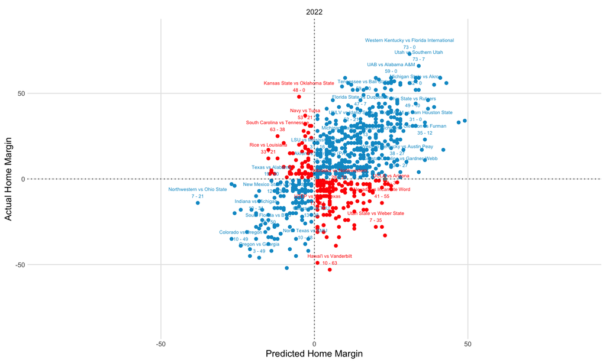

## Results

The following table shows the results of games played in previous weeks next to the model’s predictions.

| Season | Week | Quality | Home | Away | Pr(HomeWin) | Prediction | Result | Correct | correct |
| --- | --- | --- | --- | --- | --- | --- | --- | --- | --- |
| 2022 | 12 | 85 | Kentucky | Georgia | 0.136 | Georgia by 19 | Georgia by 10 | Yes | 1 |
| 2022 | 12 | 78 | Oregon | Utah | 0.620 | Oregon by 5 | Oregon by 3 | Yes | 1 |
| 2022 | 12 | 77 | Maryland | Ohio State | 0.141 | Ohio State by 18 | Ohio State by 13 | Yes | 1 |
| 2022 | 12 | 76 | Baylor | TCU | 0.399 | TCU by 5 | TCU by 1 | Yes | 1 |
| 2022 | 12 | 75 | Michigan | Illinois | 0.890 | Michigan by 23 | Michigan by 2 | Yes | 1 |
| 2022 | 12 | 71 | Arkansas | Ole Miss | 0.534 | Arkansas by 1 | Arkansas by 15 | Yes | 1 |
| 2022 | 12 | 69 | South Carolina | Tennessee | 0.249 | Tennessee by 12 | South Carolina by 25 | No | 0 |
| 2022 | 12 | 68 | Minnesota | Iowa | 0.496 | Iowa by 1 | Iowa by 3 | Yes | 1 |
| 2022 | 12 | 68 | UCLA | USC | 0.538 | UCLA by 1 | USC by 3 | No | 0 |
| 2022 | 12 | 63 | Louisville | NC State | 0.626 | Louisville by 5 | Louisville by 15 | Yes | 1 |

[output cut: 771 more lines]

# Predicting the Rest of the Season

This table displays the results of simulating the rest of the 2022 season 1000 times. These simulations are run weeks in advance, where the remainder of the season is simulated using only the information as of week 12.

For example, we simulate the entire season before any games are played by simulating week two based on the (simulated) results of week one, then simulating week three based on the (simulated) results from week two. As a result, predictions for future weeks tend to be less accurate than predictions made one week in advance and are likely to change as we get closer to the actual game.

| Season | Week | Quality | Interest | Home | Away | Pr(HomeWin) | Prediction |
| --- | --- | --- | --- | --- | --- | --- | --- |
| 2022 | 15 | 41 | 64 | Navy | Army | 0.487 | Army by 1 |